# IMDb Movie Database

## by Karim Elshetihy

> Briefly introduce dataset here.
- The dataset includes a lot of information about movies and actors & directors, also the countries and the financials. let's see what insight we will get from IMDb dataset.

#### Importing libraries

```python
import pandas as pd
import numpy as np
import matplotlib.pyplot as plt
```

#### Importing the Dataset

```python
path = 'IMDd-Movie-Database.csv'
data = pd.read_csv(path)
```

```python
data.head(10)
```

|  | Title | Release Date | Color/B&W | Genre | Language | Country | Rating | Lead Actor | Director Name | Lead Actor FB Likes | Cast FB Likes | Director FB Likes | Movie FB Likes | IMDb Score (1-10) | Total Reviews | Duration (min) | Gross Revenue | Budget |
| --- | --- | --- | --- | --- | --- | --- | --- | --- | --- | --- | --- | --- | --- | --- | --- | --- | --- | --- |
| 0 | Over the Hill to the Poorhouse | 15-09-1920 | Black and White | Crime | English | USA | Not Rated | Stephen Carr | Harry F. Millarde | 2.0 | 4 | 0 | 0 | 4.8 | 1.0 | 110.0 | 3000000 | 100000 |
| 1 | Metropolis | 26-01-1927 | Black and White | Drama | German | Germany | Not Rated | Brigitte Helm | Fritz Lang | 136.0 | 203 | 756 | 12000 | 8.3 | 260.0 | 145.0 | 26435 | 6000000 |
| 2 | The Broadway Melody | 11-11-1929 | Black and White | Musical | English | USA | Passed | Anita Page | Harry Beaumont | 77.0 | 109 | 4 | 167 | 6.3 | 36.0 | 100.0 | 2808000 | 379000 |
| 3 | 42nd Street | 29-08-1933 | Black and White | Comedy | English | USA | Unrated | Ginger Rogers | Lloyd Bacon | 610.0 | 995 | 24 | 439 | 7.7 | 65.0 | 89.0 | 2300000 | 439000 |
| 4 | Top Hat | 15-04-1935 | Black and White | Comedy | English | USA | Approved | Ginger Rogers | Mark Sandrich | 610.0 | 824 | 10 | 1000 | 7.8 | 66.0 | 81.0 | 3000000 | 609000 |
| 5 | Modern Times | 07-10-1936 | Black and White | Comedy | English | USA | G | Paulette Goddard | Charles Chaplin | 309.0 | 352 | 0 | 0 | 8.6 | 120.0 | 87.0 | 163245 | 1500000 |
| 6 | Snow White and the Seven Dwarfs | 02-02-1937 | Color | Animation | English | USA | Approved | Adriana Caselotti | William Cottrell | 82.0 | 229 | 0 | 0 | 7.7 | 145.0 | 83.0 | 184925485 | 2000000 |
| 7 | Gone with the Wind | 12-11-1939 | Color | Drama | English | USA | G | Hattie McDaniel | Victor Fleming | 503.0 | 1862 | 149 | 16000 | 8.2 | 157.0 | 226.0 | 198655278 | 3977000 |
| 8 | The Wizard of Oz | 09-04-1939 | Black and White | Adventure | English | USA | Passed | Margaret Hamilton | Victor Fleming | 695.0 | 2509 | 149 | 14000 | 8.1 | 213.0 | 102.0 | 22202612 | 2800000 |
| 9 | Fantasia | 18-05-1940 | Color | Animation | English | USA | G | Leopold Stokowski | James Algar | 16.0 | 16 | 11 | 3000 | 7.8 | 99.0 | 120.0 | 76400000 | 2280000 |

```python
data.info()
```

```
<class 'pandas.core.frame.DataFrame'>
RangeIndex: 3725 entries, 0 to 3724
Data columns (total 18 columns):
 #   Column               Non-Null Count  Dtype
---  ------               --------------  -----
 0   Title                3725 non-null   object
 1   Release Date         3725 non-null   object
 2   Color/B&W            3725 non-null   object
 3   Genre                3725 non-null   object
 4   Language             3723 non-null   object
 5   Country              3725 non-null   object
 6   Rating               3676 non-null   object
 7   Lead Actor           3722 non-null   object
 8   Director Name        3725 non-null   object
 9   Lead Actor FB Likes  3722 non-null   float64
 10  Cast FB Likes        3725 non-null   int64
 11  Director FB Likes    3725 non-null   int64
 12  Movie FB Likes       3725 non-null   int64
 13  IMDb Score (1-10)    3725 non-null   float64
 14  Total Reviews        3724 non-null   float64
 15  Duration (min)       3724 non-null   float64
 16  Gross Revenue        3725 non-null   int64
 17  Budget               3725 non-null   int64
dtypes: float64(4), int64(5), object(9)
memory usage: 392.9+ KB
```

```python
data.describe()
```

|  | Lead Actor FB Likes | Cast FB Likes | Director FB Likes | Movie FB Likes | IMDb Score (1-10) | Total Reviews | Duration (min) | Gross Revenue | Budget |
| --- | --- | --- | --- | --- | --- | --- | --- | --- | --- |
| count | 3722.000000 | 3725.000000 | 3725.000000 | 3725.000000 | 3725.000000 | 3724.000000 | 3724.000000 | 3.725000e+03 | 3.725000e+03 |
| mean | 7464.728103 | 11050.561611 | 793.286443 | 8614.911678 | 6.463732 | 159.881042 | 109.774705 | 4.972798e+07 | 4.436692e+07 |
| std | 15532.581521 | 18958.306272 | 3055.021574 | 20792.133048 | 1.058898 | 122.419180 | 22.849153 | 6.818220e+07 | 2.268511e+08 |
| min | 0.000000 | 0.000000 | 0.000000 | 0.000000 | 1.600000 | 1.000000 | 34.000000 | 1.620000e+02 | 2.180000e+02 |
| 25% | 713.000000 | 1784.000000 | 10.000000 | 0.000000 | 5.900000 | 71.000000 | 95.000000 | 6.409206e+06 | 9.000000e+06 |
| 50% | 1000.000000 | 3785.000000 | 58.000000 | 171.000000 | 6.600000 | 131.000000 | 105.000000 | 2.683000e+07 | 2.350000e+07 |
| 75% | 12000.000000 | 15716.000000 | 221.000000 | 10000.000000 | 7.200000 | 217.000000 | 120.000000 | 6.445932e+07 | 5.000000e+07 |
| max | 640000.000000 | 656730.000000 | 23000.000000 | 349000.000000 | 9.300000 | 813.000000 | 330.000000 | 7.605058e+08 | 1.221550e+10 |

```python
data.shape
```

```
(3725, 18)
```

### Find the Mean, Median, Standard Deviation

#### Mean

```python
data.mean()
```

```
Lead Actor FB Likes    7.464728e+03
Cast FB Likes          1.105056e+04
Director FB Likes      7.932864e+02
Movie FB Likes         8.614912e+03
IMDb Score (1-10)      6.463732e+00
Total Reviews          1.598810e+02
Duration (min)         1.097747e+02
Gross Revenue          4.972798e+07
Budget                 4.436692e+07
dtype: float64
```

#### Standard Deviation

```python
data.std()
```

```
Lead Actor FB Likes    1.553258e+04
Cast FB Likes          1.895831e+04
Director FB Likes      3.055022e+03
Movie FB Likes         2.079213e+04
IMDb Score (1-10)      1.058898e+00
Total Reviews          1.224192e+02
Duration (min)         2.284915e+01
Gross Revenue          6.818220e+07
Budget                 2.268511e+08
dtype: float64
```

#### Median

```python
data.median()
```

```
Lead Actor FB Likes        1000.0
Cast FB Likes              3785.0
Director FB Likes            58.0
Movie FB Likes              171.0
IMDb Score (1-10)             6.6
Total Reviews               131.0
Duration (min)              105.0
Gross Revenue          26830000.0
Budget                 23500000.0
dtype: float64
```

### **Create a normalized form whose values range exactly between 0 and 1 so that the minimum has value 0 and maximum has value 1.**

#### Data Normalization

```python
data_matrix = data.select_dtypes(['int64', 'float64'])
data_normalised = (data_matrix - data_matrix.min()) / (data_matrix.max() - data_matrix.min())
```

```python
data_normalised.head()
```

|  | Lead Actor FB Likes | Cast FB Likes | Director FB Likes | Movie FB Likes | IMDb Score (1-10) | Total Reviews | Duration (min) | Gross Revenue | Budget |
| --- | --- | --- | --- | --- | --- | --- | --- | --- | --- |
| 0 | 0.000003 | 0.000006 | 0.000000 | 0.000000 | 0.415584 | 0.000000 | 0.256757 | 0.003945 | 0.000008 |
| 1 | 0.000212 | 0.000309 | 0.032870 | 0.034384 | 0.870130 | 0.318966 | 0.375000 | 0.000035 | 0.000491 |
| 2 | 0.000120 | 0.000166 | 0.000174 | 0.000479 | 0.610390 | 0.043103 | 0.222973 | 0.003692 | 0.000031 |
| 3 | 0.000953 | 0.001515 | 0.001043 | 0.001258 | 0.792208 | 0.078818 | 0.185811 | 0.003024 | 0.000036 |
| 4 | 0.000953 | 0.001255 | 0.000435 | 0.002865 | 0.805195 | 0.080049 | 0.158784 | 0.003945 | 0.000050 |

#### Data Standarization

```python
data_standarization = (data_matrix - data_matrix.mean()) / data_matrix.std()
```

```python
data_standarization.std()
```

```
Lead Actor FB Likes    1.0
Cast FB Likes          1.0
Director FB Likes      1.0
Movie FB Likes         1.0
IMDb Score (1-10)      1.0
Total Reviews          1.0
Duration (min)         1.0
Gross Revenue          1.0
Budget                 1.0
dtype: float64
```

```python
data_standarization.mean()
```

```
Lead Actor FB Likes    2.015821e-16
Cast FB Likes         -5.010161e-17
Director FB Likes      1.457224e-16
Movie FB Likes        -6.477503e-15
IMDb Score (1-10)     -8.912781e-16
Total Reviews          8.251396e-16
Duration (min)        -1.163308e-16
Gross Revenue          1.999892e-17
Budget                 3.714404e-17
dtype: float64
```

### **Compute the Softmax score**

```python
def softmax(vector):
    softmax = np.exp(vector)
    return softmax / softmax.sum()
```

```python
# convert list of numbers to a list of probabilities
softmax = softmax(data_normalised)
softmax
```

|  | Lead Actor FB Likes | Cast FB Likes | Director FB Likes | Movie FB Likes | IMDb Score (1-10) | Total Reviews | Duration (min) | Gross Revenue | Budget |
| --- | --- | --- | --- | --- | --- | --- | --- | --- | --- |
| 0 | 0.000265 | 0.000264 | 0.000257 | 0.000261 | 0.000214 | 0.000218 | 0.000268 | 0.000251 | 0.000267 |
| 1 | 0.000266 | 0.000264 | 0.000265 | 0.000271 | 0.000338 | 0.000300 | 0.000302 | 0.000250 | 0.000268 |
| 2 | 0.000265 | 0.000264 | 0.000257 | 0.000262 | 0.000260 | 0.000228 | 0.000259 | 0.000251 | 0.000267 |
| 3 | 0.000266 | 0.000264 | 0.000257 | 0.000262 | 0.000312 | 0.000236 | 0.000250 | 0.000251 | 0.000267 |
| 4 | 0.000266 | 0.000264 | 0.000257 | 0.000262 | 0.000316 | 0.000236 | 0.000243 | 0.000251 | 0.000267 |
| ... | ... | ... | ... | ... | ... | ... | ... | ... | ... |
| 3720 | 0.000266 | 0.000264 | 0.000257 | 0.000261 | 0.000232 | 0.000243 | 0.000251 | 0.000254 | 0.000268 |
| 3721 | 0.000276 | 0.000281 | 0.000257 | 0.000283 | 0.000254 | 0.000280 | 0.000258 | 0.000271 | 0.000268 |
| 3722 | 0.000270 | 0.000269 | 0.000258 | 0.000270 | 0.000250 | 0.000265 | 0.000268 | 0.000252 | 0.000268 |
| 3723 | 0.000266 | 0.000265 | 0.000257 | 0.000261 | 0.000254 | 0.000265 | 0.000256 | 0.000252 | 0.000267 |
| 3724 | 0.000272 | 0.000271 | 0.000257 | 0.000288 | 0.000297 | 0.000280 | 0.000267 | 0.000262 | 0.000268 |

3725 rows × 9 columns

```python
np.sum(softmax)
```

```
Lead Actor FB Likes    1.0
Cast FB Likes          1.0
Director FB Likes      1.0
Movie FB Likes         1.0
IMDb Score (1-10)      1.0
Total Reviews          1.0
Duration (min)         1.0
Gross Revenue          1.0
Budget                 1.0
dtype: float64
```

```python
softmax.shape
```

```
(3725, 9)
```

### **Find the number and position of missing values**

```python
data.isnull().sum()
```

```
Title                   0
Release Date            0
Color/B&W               0
Genre                   0
Language                2
Country                 0
Rating                 49
Lead Actor              3
Director Name           0
Lead Actor FB Likes     3
Cast FB Likes           0
Director FB Likes       0
Movie FB Likes          0
IMDb Score (1-10)       0
Total Reviews           1
Duration (min)          1
Gross Revenue           0
Budget                  0
dtype: int64
```

```python
null_data = pd.DataFrame(data[data.isnull().any(axis=1)])
null_data
```

|  | Title | Release Date | Color/B&W | Genre | Language | Country | Rating | Lead Actor | Director Name | Lead Actor FB Likes | Cast FB Likes | Director FB Likes | Movie FB Likes | IMDb Score (1-10) | Total Reviews | Duration (min) | Gross Revenue | Budget |
| --- | --- | --- | --- | --- | --- | --- | --- | --- | --- | --- | --- | --- | --- | --- | --- | --- | --- | --- |
| 316 | Marilyn Hotchkiss' Ballroom Dancing and Charm ... | 16-01-1990 | Color | Comedy | English | USA | NaN | William Hurt | Randall Miller | 882.0 | 1967 | 19 | 16 | 7.1 | 1.0 | 34.0 | 333658 | 34000 |
| 408 | Madadayo | 05-09-1993 | Color | Drama | Japanese | Japan | NaN | Tatsuo Matsumura | Akira Kurosawa | 15.0 | 30 | 0 | 355 | 7.5 | 25.0 | 134.0 | 48856 | 11900000 |
| 517 | Kids | 10-12-1995 | Color | Drama | English | USA | NaN | Rosario Dawson | Larry Clark | 3000.0 | 3310 | 184 | 0 | 7.0 | 71.0 | 91.0 | 7417210 | 1500000 |
| 726 | The Cure | 08-12-1997 | Color | Crime | Japanese | Japan | NaN | Kôji Yakusho | Kiyoshi Kurosawa | 89.0 | 115 | 62 | 817 | 7.4 | 78.0 | 111.0 | 94596 | 1000000 |
| 743 | The Sticky Fingers of Time | 17-12-1997 | Black and White | Sci-Fi | English | USA | NaN | James Urbaniak | Hilary Brougher | 119.0 | 154 | 0 | 67 | 6.3 | 8.0 | 81.0 | 18195 | 250000 |
| 745 | The Swindle | 27-12-1997 | Color | Comedy | French | France | NaN | Isabelle Huppert | Claude Chabrol | 678.0 | 1256 | 324 | 33 | 6.6 | 34.0 | 101.0 | 231417 | 60000000 |
| 793 | Happiness | 15-03-1998 | Color | Comedy | English | USA | NaN | Philip Seymour Hoffman | Todd Solondz | 22000.0 | 36859 | 377 | 0 | 7.8 | 148.0 | 134.0 | 3000000 | 3000000 |
| 804 | Les couloirs du temps: Les visiteurs II | 12-08-1998 | Color | Comedy | French | France | NaN | Christian Clavier | Jean-Marie Poiré | 106.0 | 182 | 8 | 136 | 6.0 | 8.0 | 118.0 | 146072 | 140000000 |
| 880 | Aimee & Jaguar | 22-10-1999 | Color | Biography | German | Germany | NaN | Heike Makatsch | Max Färberböck | 177.0 | 333 | 4 | 687 | 7.3 | 63.0 | 125.0 | 927107 | 15000000 |
| 1023 | The Woman Chaser | 19-02-1999 | Black and White | Comedy | English | USA | NaN | Marilyn Rising | Robinson Devor | 142.0 | 168 | 14 | 73 | 7.3 | 18.0 | 88.0 | 110720 | 1200000 |
| 1039 | Aberdeen | 11-02-2000 | Color | Drama | English | UK | NaN | Charlotte Rampling | Hans Petter Moland | 844.0 | 846 | 19 | 260 | 7.3 | 28.0 | 106.0 | 64148 | 6500000 |
| 1079 | Fiza | 12-11-2000 | Black and White | Drama | Hindi | India | NaN | Karisma Kapoor | Khalid Mohamed | 353.0 | 773 | 10 | 92 | 6.2 | 1.0 | 167.0 | 610991 | 1000000 |
| 1202 | Alias Betty | 24-04-2001 | Color | Comedy | French | France | NaN | Sandrine Kiberlain | Claude Miller | 71.0 | 262 | 27 | 26 | 6.9 | 38.0 | 103.0 | 206400 | 50000000 |
| 1213 | Ayurveda: Art of Being | 04-09-2001 | Color | Documentary | English | India | NaN | NaN | Pan Nalin | NaN | 0 | 95 | 379 | 7.6 | 15.0 | 102.0 | 16892 | 300000 |
| 1422 | Dracula: Pages from a Virgin's Diary | 27-03-2002 | Black and White | Comedy | English | Canada | NaN | Sarah Murphy-Dyson | Guy Maddin | 14.0 | 21 | 126 | 131 | 7.0 | 58.0 | 73.0 | 39659 | 1600000 |
| 1515 | The Business of Fancydancing | 28-07-2002 | Color | Drama | English | USA | NaN | William Joseph Elk III | Sherman Alexie | 96.0 | 314 | 18 | 96 | 6.9 | 12.0 | 103.0 | 174682 | 200000 |
| 1603 | Gory Gory Hallelujah | 27-11-2003 | Color | Comedy | English | USA | NaN | Tony Doupe | Sue Corcoran | 361.0 | 387 | 14 | 39 | 4.7 | 8.0 | 96.0 | 11798 | 100000 |
| 1702 | Travelers and Magicians | 30-05-2003 | Color | Adventure | Dzongkha | Australia | NaN | Tshewang Dendup | Khyentse Norbu | 0.0 | 0 | 28 | 353 | 7.5 | 44.0 | 108.0 | 505295 | 1800000 |
| 1726 | As It Is in Heaven | 10-05-2004 | Color | Comedy | Swedish | Sweden | NaN | Michael Nyqvist | Kay Pollak | 690.0 | 774 | 10 | 0 | 7.6 | 34.0 | 133.0 | 9910 | 25000000 |
| 1750 | Dead Man's Shoes | 23-08-2004 | Black and White | Crime | English | UK | NaN | Paddy Considine | Shane Meadows | 680.0 | 1311 | 222 | 0 | 7.7 | 99.0 | 90.0 | 6013 | 695393 |
| 1879 | Veer-Zaara | 12-07-2004 | Color | Drama | Hindi | India | NaN | Shah Rukh Khan | Yash Chopra | 8000.0 | 9984 | 147 | 2000 | 7.9 | 29.0 | 192.0 | 2921738 | 7000000 |
| 1911 | Chocolate: Deep Dark Secrets | 14-03-2005 | Color | Thriller | Hindi | India | NaN | Emraan Hashmi | Vivek Agnihotri | 724.0 | 2024 | 5 | 31 | 4.8 | 4.0 | 160.0 | 49000 | 1500000 |
| 1923 | Dil Jo Bhi Kahey... | 11-05-2005 | Color | Romance | English | India | NaN | Annabelle Wallis | Romesh Sharma | 421.0 | 622 | 0 | 9 | 5.1 | 4.0 | NaN | 129319 | 70000000 |
| 1986 | Neal 'N' Nikki | 05-11-2005 | Color | Comedy | English | India | NaN | Abhishek Bachchan | Arjun Sablok | 374.0 | 602 | 0 | 66 | 3.3 | 5.0 | 97.0 | 100358 | 1500000 |
| 2158 | Love's Abiding Joy | 24-06-2006 | Color | Drama | NaN | USA | PG | William Morgan Sheppard | Michael Landon Jr. | 702.0 | 2715 | 84 | 76 | 7.2 | 5.0 | 87.0 | 252726 | 3000000 |
| 2253 | Valley of the Heart's Delight | 16-09-2006 | Color | Drama | English | USA | NaN | Bruce McGill | Tim Boxell | 655.0 | 1064 | 10 | 144 | 6.6 | 3.0 | 100.0 | 118666 | 2500000 |
| 2274 | Arnolds Park | 28-08-2007 | Color | Mystery | English | USA | PG-13 | Kendyl Joi | Gene Teigland | 23.0 | 85 | 0 | 11 | 5.6 | NaN | 103.0 | 23616 | 600000 |
| 2286 | Certifiably Jonathan | 30-08-2007 | Color | Comedy | English | USA | NaN | Robin Williams | James David Pasternak | 49000.0 | 54484 | 0 | 87 | 6.2 | 17.0 | 85.0 | 7826 | 1200000 |
| 2343 | No End in Sight | 15-06-2007 | Color | Documentary | English | USA | NaN | Campbell Scott | Charles Ferguson | 393.0 | 446 | 117 | 0 | 8.3 | 79.0 | 102.0 | 1430185 | 2000000 |
| 2362 | September Dawn | 11-11-2007 | Color | Drama | NaN | USA | R | Jon Gries | Christopher Cain | 482.0 | 1526 | 58 | 411 | 5.8 | 43.0 | 111.0 | 1066555 | 11000000 |
| 2373 | Ta Ra Rum Pum | 24-02-2007 | Color | Comedy | Hindi | USA | NaN | Saif Ali Khan | Siddharth Anand | 532.0 | 902 | 5 | 108 | 5.4 | 16.0 | 153.0 | 872643 | 6000000 |
| 2442 | Dolphins and Whales 3D: Tribes of the Ocean | 23-06-2008 | Color | Adventure | English | UK | NaN | Charlotte Rampling | Jean-Jacques Mantello | 844.0 | 844 | 0 | 28 | 6.5 | 9.0 | 42.0 | 7518876 | 6000000 |
| 2624 | Breaking Upwards | 03-06-2009 | Color | Romance | English | USA | NaN | Zoe Lister-Jones | Daryl Wein | 331.0 | 1546 | 38 | 324 | 6.2 | 22.0 | 88.0 | 76382 | 15000 |
| 2702 | Paa | 02-11-2009 | Color | Comedy | Hindi | India | NaN | Vidya Balan | R. Balki | 464.0 | 1045 | 12 | 504 | 7.2 | 12.0 | 133.0 | 199228 | 150000000 |
| 2717 | Soul Kitchen | 24-07-2009 | Color | Comedy | German | Germany | NaN | Udo Kier | Fatih Akin | 595.0 | 1519 | 766 | 0 | 7.3 | 115.0 | 99.0 | 274385 | 4000000 |
| 2749 | The Missing Person | 18-12-2009 | Color | Drama | English | USA | NaN | Merritt Wever | Noah Buschel | 529.0 | 2749 | 8 | 195 | 6.2 | 66.0 | 95.0 | 17580 | 1500000 |
| 2839 | Kites | 16-04-2010 | Color | Action | English | India | NaN | Bárbara Mori | Anurag Basu | 594.0 | 1836 | 116 | 0 | 6.0 | 41.0 | 90.0 | 1602466 | 600000000 |
| 2881 | Sea Rex 3D: Journey to a Prehistoric World | 29-07-2010 | Color | Documentary | English | UK | NaN | Norbert Ferrer | Ronan Chapalain | 55.0 | 55 | 0 | 89 | 6.9 | 7.0 | 41.0 | 4074023 | 5000000 |
| 3042 | Pink Ribbons, Inc. | 12-10-2011 | Color | Documentary | English | Canada | Not Rated | NaN | Léa Pool | NaN | 0 | 4 | 5000 | 7.4 | 23.0 | 97.0 | 24784 | 1200000 |
| 3091 | The Harvest/La Cosecha | 22-03-2011 | Color | Documentary | English | USA | NaN | NaN | U. Roberto Romano | NaN | 0 | 6 | 88 | 7.2 | 3.0 | 80.0 | 2245 | 560000 |
| 3152 | Deceptive Practice: The Mysteries and Mentors ... | 12-02-2012 | Color | Documentary | English | USA | NaN | David Mamet | Molly Bernstein | 342.0 | 483 | 0 | 590 | 7.1 | 39.0 | 88.0 | 151389 | 500000 |
| 3368 | Of Horses and Men | 12-06-2013 | Color | Comedy | Icelandic | Iceland | NaN | Ingvar Eggert Sigurðsson | Benedikt Erlingsson | 63.0 | 81 | 4 | 1000 | 6.9 | 66.0 | 81.0 | 11835 | 10000000 |
| 3397 | The Amazing Catfish | 23-11-2013 | Color | Comedy | Spanish | Mexico | NaN | Ximena Ayala | Claudia Sainte-Luce | 31.0 | 58 | 0 | 407 | 7.0 | 50.0 | 89.0 | 11278 | 1300000 |
| 3419 | The Knife of Don Juan | 24-04-2013 | Color | Comedy | Spanish | USA | NaN | Nataniel Sánchez | Tom Sanchez | 3.0 | 5 | 0 | 75 | 7.2 | 1.0 | 110.0 | 3830 | 1200000 |
| 3439 | Thunder and the House of Magic | 24-06-2013 | Color | Adventure | English | Belgium | NaN | Kyle Hebert | Jeremy Degruson | 324.0 | 369 | 0 | 0 | 6.3 | 60.0 | 85.0 | 4091 | 34000000 |
| 3473 | Born to Fly: Elizabeth Streb vs. Gravity | 03-08-2014 | Color | Action | English | USA | NaN | Elizabeth Streb | Catherine Gund | 0.0 | 0 | 0 | 44 | 6.8 | 10.0 | 82.0 | 21199 | 500000 |
| 3512 | Kung Fu Killer | 24-09-2014 | Color | Action | Cantonese | China | NaN | Siu-Wong Fan | Teddy Chan | 79.0 | 285 | 3 | 0 | 6.5 | 65.0 | 100.0 | 129115 | 25000000 |
| 3585 | Top Spin | 15-03-2014 | Color | Documentary | English | USA | NaN | Ariel Hsing | Sara Newens | 0.0 | 0 | 0 | 116 | 7.1 | 18.0 | 80.0 | 5858 | 150000 |
| 3603 | Antarctic Edge: 70° South | 22-02-2015 | Color | Adventure | English | USA | NaN | Naderev Sano | Dena Seidel | 0.0 | 0 | 0 | 215 | 7.0 | 5.0 | 72.0 | 4914 | 150000 |
| 3606 | Baahubali: The Beginning | 27-06-2015 | Color | Action | Telugu | India | NaN | Tamannaah Bhatia | S.S. Rajamouli | 218.0 | 554 | 50 | 21000 | 8.4 | 44.0 | 159.0 | 6498000 | 18026148 |
| 3615 | Censored Voices | 29-09-2015 | Color | Documentary | Hebrew | Israel | NaN | Amos Oz | Mor Loushy | 3.0 | 3 | 0 | 111 | 7.2 | 23.0 | 84.0 | 34151 | 450000 |
| 3672 | Road Hard | 03-11-2015 | Color | Comedy | English | USA | NaN | Jay Mohr | Adam Carolla | 563.0 | 2628 | 102 | 212 | 6.1 | 14.0 | 98.0 | 105943 | 1500000 |
| 3717 | Time to Choose | 27-04-2015 | Color | Documentary | English | USA | NaN | Jane Goodall | Charles Ferguson | 21.0 | 24 | 117 | 121 | 7.0 | 6.0 | 100.0 | 29233 | 3500000 |

```python
null_data.shape
```

```
(53, 18)
```

### **Select the rows that does not have any value**

```python
no_value = pd.DataFrame(data[data.isnull().all(axis=1)])
no_value
```

|  | Title | Release Date | Color/B&W | Genre | Language | Country | Rating | Lead Actor | Director Name | Lead Actor FB Likes | Cast FB Likes | Director FB Likes | Movie FB Likes | IMDb Score (1-10) | Total Reviews | Duration (min) | Gross Revenue | Budget |
| --- | --- | --- | --- | --- | --- | --- | --- | --- | --- | --- | --- | --- | --- | --- | --- | --- | --- | --- |

### **Find the unique values and the count of unique values**

```python
data.nunique()
```

```
Title                  3725
Release Date           3055
Color/B&W                 2
Genre                    17
Language                 38
Country                  46
Rating                   12
Lead Actor             1494
Director Name          1733
Lead Actor FB Likes     734
Cast FB Likes          3257
Director FB Likes       400
Movie FB Likes          697
IMDb Score (1-10)        74
Total Reviews           525
Duration (min)          155
Gross Revenue          3704
Budget                  370
dtype: int64
```

```python
unique_values = {}
for column in data.columns:
    unique_values[column] = data[column].unique()
    print(column,':',unique_values[column],'\n')
```

```
Title : ['Over the Hill to the Poorhouse' 'Metropolis' 'The Broadway Melody' ...
 'Victor Frankenstein' 'We Are Your Friends' 'Woman in Gold']

Release Date : ['15-09-1920' '26-01-1927' '11-11-1929' ... '03-08-2015' '14-05-2015'
 '17-02-2015']

Color/B&W : ['Black and White' 'Color']

Genre : ['Crime' 'Drama' 'Musical' 'Comedy' 'Animation' 'Adventure' 'Biography'
 'Action' 'Horror' 'Western' 'Documentary' 'Mystery' 'Fantasy' 'Sci-Fi'
 'Family' 'Thriller' 'Romance']

Language : ['English' 'German' 'Japanese' 'Italian' 'French' 'Spanish' 'Cantonese'
 'Dutch' 'Persian' 'Portuguese' 'Danish' 'Mandarin' 'Hindi' 'Norwegian'
 'Thai' 'Aboriginal' 'Korean' 'Dari' 'Dzongkha' 'Swedish' 'Russian'
 'Aramaic' 'Hungarian' 'Kazakh' 'Filipino' 'Zulu' 'Maya' 'Czech'
 'Vietnamese' nan 'Hebrew' 'Romanian' 'Arabic' 'Mongolian' 'Bosnian'
 'None' 'Indonesian' 'Icelandic' 'Telugu']

Country : ['USA' 'Germany' 'Japan' 'UK' 'Italy' 'France' 'Iran' 'West Germany'
 'Australia' 'Canada' 'China' 'New Zealand' 'Hong Kong' 'Peru'
 'Netherlands' 'Denmark' 'Brazil' 'Aruba' 'Mexico' 'Spain'
 'Czech Republic' 'Taiwan' 'India' 'Argentina' 'Norway' 'Thailand'
 'New Line' 'South Korea' 'Afghanistan' 'Ireland' 'Sweden' 'Colombia'
 'Russia' 'Romania' 'Philippines' 'Hungary' 'Israel' 'Poland'
 'South Africa' 'Iceland' 'Official site' 'Georgia' 'Finland' 'Belgium'
 'Indonesia' 'Chile']

Rating : ['Not Rated' 'Passed' 'Unrated' 'Approved' 'G' 'PG' 'R' 'PG-13' 'M' 'X'
 'GP' 'NC-17' nan]

Lead Actor : ['Stephen Carr' 'Brigitte Helm' 'Anita Page' ... 'Jane Goodall'
 'Amy Schumer' 'Vanessa Lengies']

Director Name : ['Harry F. Millarde' 'Fritz Lang' 'Harry Beaumont' ... 'Robert Eggers'
 'John Francis Daley' 'Max Joseph']

Lead Actor FB Likes : [2.00e+00 1.36e+02 7.70e+01 6.10e+02 3.09e+02 8.20e+01 5.03e+02 6.95e+02
 1.60e+01 1.00e+03 4.69e+02 7.49e+02 8.90e+01 2.77e+02 2.32e+02 5.70e+01
 7.26e+02 1.00e+04 3.04e+02 6.82e+02 1.05e+02 6.06e+02 8.04e+02 6.50e+02
```

[output cut: 305 more lines]

[output not shown]

### **Find the most frequent value of dataset**

Here we can find that the column **Gross Revenue** has two frequent values.

```python
data.drop('Title', axis=1).mode()
```

|  | Release Date | Color/B&W | Genre | Language | Country | Rating | Lead Actor | Director Name | Lead Actor FB Likes | Cast FB Likes | Director FB Likes | Movie FB Likes | IMDb Score (1-10) | Total Reviews | Duration (min) | Gross Revenue | Budget |
| --- | --- | --- | --- | --- | --- | --- | --- | --- | --- | --- | --- | --- | --- | --- | --- | --- | --- |
| 0 | 08-04-2004 | Color | Comedy | English | USA | R | Robert De Niro | Steven Spielberg | 1000.0 | 0.0 | 0.0 | 0.0 | 6.7 | 81.0 | 101.0 | 3000000 | 20000000.0 |
| 1 | NaN | NaN | NaN | NaN | NaN | NaN | NaN | NaN | NaN | NaN | NaN | NaN | NaN | NaN | NaN | 8000000 | NaN |

#### Duplicated Data

```python
data['Title'].duplicated().sum()
```

```
0
```

### Cleaning Data

#### Drop down Null Values

```python
data.dropna(inplace=True)
```

```python
data[data.isnull().any(axis=1)]
```

|  | Title | Release Date | Color/B&W | Genre | Language | Country | Rating | Lead Actor | Director Name | Lead Actor FB Likes | Cast FB Likes | Director FB Likes | Movie FB Likes | IMDb Score (1-10) | Total Reviews | Duration (min) | Gross Revenue | Budget |
| --- | --- | --- | --- | --- | --- | --- | --- | --- | --- | --- | --- | --- | --- | --- | --- | --- | --- | --- |

```python
data.shape
```

```
(3672, 18)
```

#### Converting "Lead Actor FB Likes" & "Duration" columns to integers

```python
data['Lead Actor FB Likes'] = data['Lead Actor FB Likes'].astype('int64')
data['Duration (min)'] = data['Duration (min)'].astype('int64')
```

```python
data.info()
```

```
<class 'pandas.core.frame.DataFrame'>
Int64Index: 3672 entries, 0 to 3724
Data columns (total 18 columns):
 #   Column               Non-Null Count  Dtype
---  ------               --------------  -----
 0   Title                3672 non-null   object
 1   Release Date         3672 non-null   object
 2   Color/B&W            3672 non-null   object
 3   Genre                3672 non-null   object
 4   Language             3672 non-null   object
 5   Country              3672 non-null   object
 6   Rating               3672 non-null   object
 7   Lead Actor           3672 non-null   object
 8   Director Name        3672 non-null   object
 9   Lead Actor FB Likes  3672 non-null   int64
 10  Cast FB Likes        3672 non-null   int64
 11  Director FB Likes    3672 non-null   int64
 12  Movie FB Likes       3672 non-null   int64
 13  IMDb Score (1-10)    3672 non-null   float64
 14  Total Reviews        3672 non-null   float64
 15  Duration (min)       3672 non-null   int64
 16  Gross Revenue        3672 non-null   int64
 17  Budget               3672 non-null   int64
dtypes: float64(2), int64(7), object(9)
memory usage: 416.0+ KB
```

#### Fix Ratings (Not Rated, Unrated, G, PG, R, PG-13, M, X, GP, NC-17)

The certificates section records the ratings certificates given to titles within each country.

- https://help.imdb.com/article/contribution/titles/certificates/GU757M8ZJ9ZPXB39?ref_=helpart_nav_27#

**Australia**

- **G** - General
- **PG** - Parental Guidance for under 15
- **M** - 15+ Recommended
- **R** - Passed only for persons 18 and over
- **X** - Sexually Explicit, 18s and over (Possibly only videos)

**Canada**

- **G** - Suitable for all
- **PG** - Parental Guidance
- **R** - Passed only for persons 18 and over
- **PG-13** - Teens
- **NC-17** - Adult

**USA**

- **Approved** - Pre-1968 titles only (from the MPA site) Under the Hays Code, films were simply approved or disapproved based on whether they were deemed 'moral' or 'immoral'.)

etc...

Here we can find the ratings we need to make the data more clear for the audience. You can find more information at the link above.

```python
data['Rating'].replace('G','General', inplace=True)
data['Rating'].replace('PG','Parental Guidance', inplace=True)
data['Rating'].replace('GP','Parental Guidance', inplace=True)
data['Rating'].replace('R','Over 18', inplace=True)
data['Rating'].replace('PG-13','Teens', inplace=True)
data['Rating'].replace('M','Teens', inplace=True)
data['Rating'].replace('NC-17','Adult', inplace=True)
data['Rating'].replace('X','Sexually Explicit', inplace=True)
data['Rating'].replace('Not Rated','Unrated', inplace=True)
```

```python
data['Rating'].unique()
```

```
array(['Unrated', 'Passed', 'Approved', 'General', 'Parental Guidance',
       'Over 18', 'Teens', 'Sexually Explicit', 'Adult'], dtype=object)
```

### Normalising & Standarizinng Data after Cleaning

#### Data Normalization

```python
data_matrix = data.select_dtypes(['int64', 'float64'])
data_normalised = (data_matrix - data_matrix.min()) / (data_matrix.max() - data_matrix.min())
```

```python
data_normalised.head()
```

|  | Lead Actor FB Likes | Cast FB Likes | Director FB Likes | Movie FB Likes | IMDb Score (1-10) | Total Reviews | Duration (min) | Gross Revenue | Budget |
| --- | --- | --- | --- | --- | --- | --- | --- | --- | --- |
| 0 | 0.000003 | 0.000006 | 0.000000 | 0.000000 | 0.415584 | 0.000000 | 0.249147 | 0.003945 | 0.000008 |
| 1 | 0.000212 | 0.000309 | 0.032870 | 0.034384 | 0.870130 | 0.318966 | 0.368601 | 0.000035 | 0.000491 |
| 2 | 0.000120 | 0.000166 | 0.000174 | 0.000479 | 0.610390 | 0.043103 | 0.215017 | 0.003692 | 0.000031 |
| 3 | 0.000953 | 0.001515 | 0.001043 | 0.001258 | 0.792208 | 0.078818 | 0.177474 | 0.003024 | 0.000036 |
| 4 | 0.000953 | 0.001255 | 0.000435 | 0.002865 | 0.805195 | 0.080049 | 0.150171 | 0.003945 | 0.000050 |

#### Data Standarization

```python
data_standarization = (data_matrix - data_matrix.mean()) / data_matrix.std()
```

```python
data_standarization.head()
```

|  | Lead Actor FB Likes | Cast FB Likes | Director FB Likes | Movie FB Likes | IMDb Score (1-10) | Total Reviews | Duration (min) | Gross Revenue | Budget |
| --- | --- | --- | --- | --- | --- | --- | --- | --- | --- |
| 0 | -0.483200 | -0.586656 | -0.261360 | -0.417334 | -1.565412 | -1.314092 | 0.004794 | -0.693318 | -0.195213 |
| 1 | -0.474611 | -0.576203 | -0.015561 | 0.156368 | 1.735762 | 0.804045 | 1.545195 | -0.736781 | -0.169363 |
| 2 | -0.478393 | -0.581141 | -0.260060 | -0.409350 | -0.150623 | -1.027857 | -0.435320 | -0.696125 | -0.193991 |
| 3 | -0.444227 | -0.534602 | -0.253557 | -0.396346 | 1.169847 | -0.790691 | -0.919446 | -0.703550 | -0.193728 |
| 4 | -0.444227 | -0.543584 | -0.258109 | -0.369525 | 1.264166 | -0.782513 | -1.271538 | -0.693318 | -0.192983 |

```python
data_standarization.std()
```

```
Lead Actor FB Likes    1.0
Cast FB Likes          1.0
Director FB Likes      1.0
Movie FB Likes         1.0
IMDb Score (1-10)      1.0
Total Reviews          1.0
Duration (min)         1.0
Gross Revenue          1.0
Budget                 1.0
dtype: float64
```

```python
data_standarization.mean()
```

```
Lead Actor FB Likes    8.876644e-16
Cast FB Likes         -3.269897e-17
Director FB Likes      2.802013e-17
Movie FB Likes         9.219024e-15
IMDb Score (1-10)      1.603353e-16
Total Reviews          2.426648e-16
Duration (min)        -1.410342e-16
Gross Revenue          4.796756e-17
Budget                 6.377282e-17
dtype: float64
```

#### Saving Data as "xlsx" and "csv" after cleaning

```python
data.to_csv('IMDb_Cleaned.csv', index=False)
with pd.ExcelWriter('IMDb_Cleaned.xlsx') as excel:
    data.to_excel(excel, sheet_name='Cleaned_data', index=False)
    data_normalised.to_excel(excel, sheet_name='Normalized_data', index=False)
    data_standarization.to_excel(excel, sheet_name='Standarized_data', index=False)
```

### Dataset Structure

> Write the structure of your dataset here

The structure of the dataset as I understand is devided to data related to the Movies, Actors & Directors, Countries, and Financials.

**Columns that are related directly to the Movies:**

1. Title
2. Release Date
3. Color/B&W
4. Genre
5. Rating
6. Language
7. Movie FB Likes
8. IMDb Score (1-10)
9. Total Reviews
10. Duration (min)
11. Gross Revenue
12. Budget

**Columns that are related directly to the Actors & Directors:**

1. Lead Actor
2. Director Name
3. Lead Actor FB Likes
4. Cast FB Likes
5. Director FB Likes

**Columns that are related directly to the Countries:**

1. Gross Revenue
2. Budget
3. Data can be extracted from the columns above:
   - Count of actors per country.
   - Count of directors per country.
   - Total filming duration.
   - etc...

# Type of data analysis

## Univariate

> is a term commonly used in statistics to describe a type of data which consists of observations on only a single characteristic or attribute.

> Univariate analysis is the simplest form of analyzing data. “Uni” means “one”, so in other words your data has only one variable.

## Bivariate

> In statistics, bivariate data is data on each of two variables, where each value of one of the variables is paired with a value of the other variable. Typically it would be of interest to investigate the possible association between the two variables.

> Bivariate analysis is one of the simplest forms of quantitative (statistical) analysis. It involves the analysis of two variables (often denoted as X, Y), for the purpose of determining the empirical relationship between them.

## Multivariate

> Multivariate statistics is a subdivision of statistics encompassing the simultaneous observation and analysis of more than one outcome variable. The application of multivariate statistics is multivariate analysis.

> Multivariate analysis is based on the principles of multivariate statistics, which involves observation and analysis of more than one statistical outcome variable at a time.

[figure not shown]

# Univariate

> Make at least one chart ,write your observation under every chart

```python
font_size1 = 16
font_size2 = 12
```

#### Count of Colored & B/W Movies

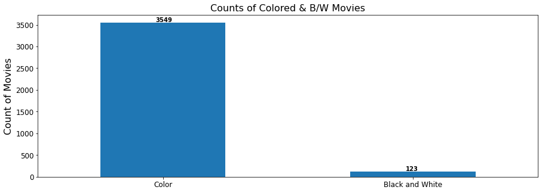

```python
data['Color/B&W'].value_counts().plot(kind="bar", figsize=(15,5));

plt.ylabel('Count of Movies', fontsize=font_size1);
plt.title('Counts of Colored & B/W Movies', fontsize=font_size1);
plt.xticks(fontsize= font_size2, rotation='horizontal');
plt.yticks(fontsize= font_size2);

for num, value in enumerate(data['Color/B&W'].value_counts()):
        plt.text(num-0.03, value+20, str(value), fontweight='bold');
```

[figure not shown]

```python
data['Color/B&W'].value_counts().plot(kind="pie", figsize=(6,6),autopct='%1.1f%%', fontsize=font_size2);

plt.ylabel('', fontsize=font_size1);
plt.title('Counts of Movies by Genre', fontsize=font_size1);
plt.xticks(fontsize= font_size2);
plt.yticks(fontsize= font_size2);
```

#### Count of Genres Movies

- People prefer Comedy movies the most, 998 were comedy movies from 3672, followed by Action movies with 896 movies.

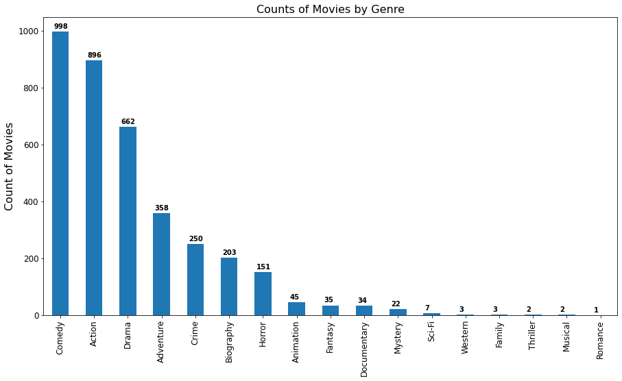

```python
data['Genre'].value_counts().plot(kind="bar", figsize=(15,8));

plt.ylabel('Count of Movies', fontsize=font_size1);
plt.title('Counts of Movies by Genre', fontsize=font_size1);
plt.xticks(fontsize= font_size2);
plt.yticks(fontsize= font_size2);

for num, value in enumerate(data['Genre'].value_counts()):
        plt.text(num-0.2, value+10, str(value), fontweight='bold');
```

#### Count of Ratings Movies

- 36 Over-18 movies were filmed yearly as they are 46% of all IMDb movies.

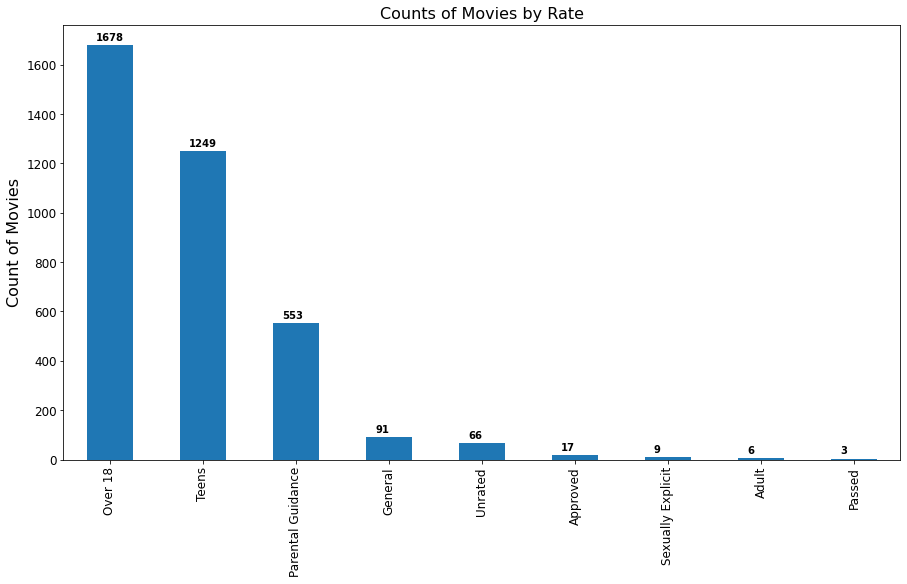

```python
data['Rating'].value_counts().plot(kind="bar", figsize=(15,8));

plt.ylabel('Count of Movies', fontsize=font_size1);
plt.title('Counts of Movies by Rate', fontsize=font_size1);
plt.xticks(fontsize= font_size2);
plt.yticks(fontsize= font_size2);

for num, value in enumerate(data['Rating'].value_counts()):
        plt.text(num-0.15, value+20, str(value), fontweight='bold');
```

#### Count of Countries Movies

- USA is the highest of course, USA is filming scince 1920 and maybe before.

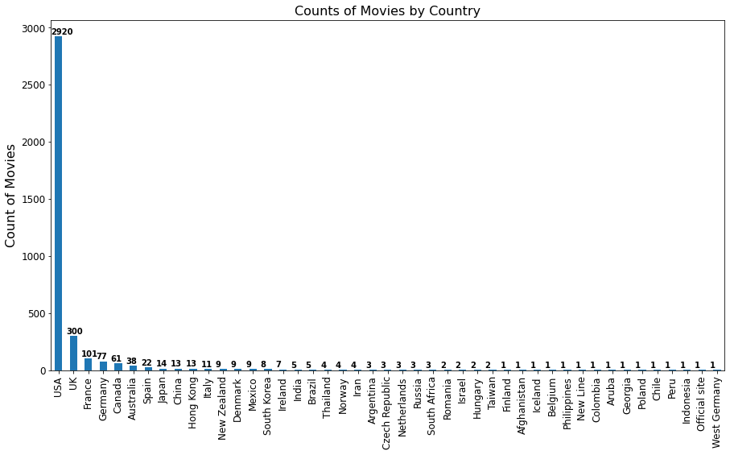

```python
data['Country'].value_counts().plot(kind="bar", figsize=(15,8));

plt.ylabel('Count of Movies', fontsize=font_size1);
plt.title('Counts of Movies by Country', fontsize=font_size1);
plt.xticks(fontsize= font_size2);
plt.yticks(fontsize= font_size2);

for num, value in enumerate(data['Country'].value_counts()):
        plt.text(num-0.5, value+20, str(value), fontweight='bold');
```

#### Count of Languages Movies

- Top lannguage is English as most of the world speaks it.

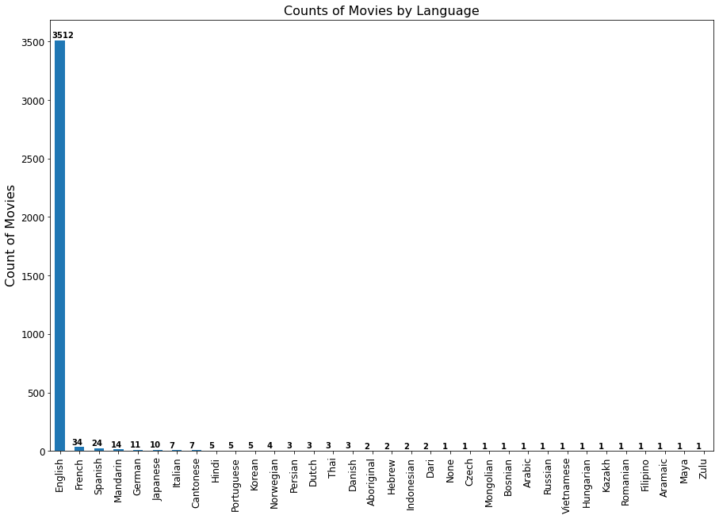

```python
data['Language'].value_counts().plot(kind="bar", figsize=(15,10));

plt.ylabel('Count of Movies', fontsize=font_size1);
plt.title('Counts of Movies by Language', fontsize=font_size1);
plt.xticks(fontsize= font_size2);
plt.yticks(fontsize= font_size2);

for num, value in enumerate(data['Language'].value_counts()):
        plt.text(num-0.4, value+20, str(value), fontweight='bold');
```

# Bivariate

> Make at least one chart ,write your observation under every chart

### Movies, Actors, & Directors Likes, IMDb Score, & Reviews

#### Top Movies by Likes

- Intersteller got the highest likes by 349,000 likes and IMDb score of 8.6, followed by Django Unchained with 199,000 likes and score of 8.5.

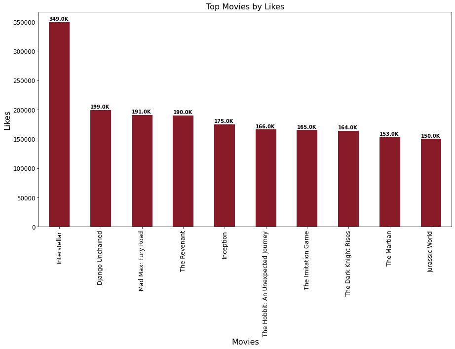

```python
data.groupby('Title')['Movie FB Likes'].sum().nlargest(10).plot(kind='bar', figsize=(15,8), color='#871b28');
plt.xlabel('Movies', fontsize=font_size1);
plt.ylabel('Likes', fontsize=font_size1);
plt.title('Top Movies by Likes', fontsize=font_size1);
plt.xticks(fontsize= font_size2);
plt.yticks(fontsize= font_size2);

for num, value in enumerate(data.groupby('Title')['Movie FB Likes'].sum().nlargest(10)):
        plt.text(num-0.25, value+np.exp(8), str(np.round(value/1000, decimals = 1))+'K', fontweight='bold');
```

#### Top Movies by IMDb Score

- The Shawshank Redemption has highest score on IMDb.

[figure not shown]

```python
data.groupby('Title')['IMDb Score (1-10)'].sum().nlargest(10).plot(kind='bar', figsize=(15,8), color='#871b28');
plt.xlabel('Movies', fontsize=font_size1);
plt.ylabel('IMDb Score', fontsize=font_size1);
plt.title('Top Movies by IMDb Score', fontsize=font_size1);
plt.xticks(fontsize= font_size2);
plt.yticks(fontsize= font_size2);

for num, value in enumerate(data.groupby('Title')['IMDb Score (1-10)'].sum().nlargest(10)):
        plt.text(num-0.15, value+0.1, str(np.round(value, decimals = 1)), fontweight='bold');
```

#### Top Movies by Reviews

- The Dark Knight Rises got the highest reviews by 813 reviews.

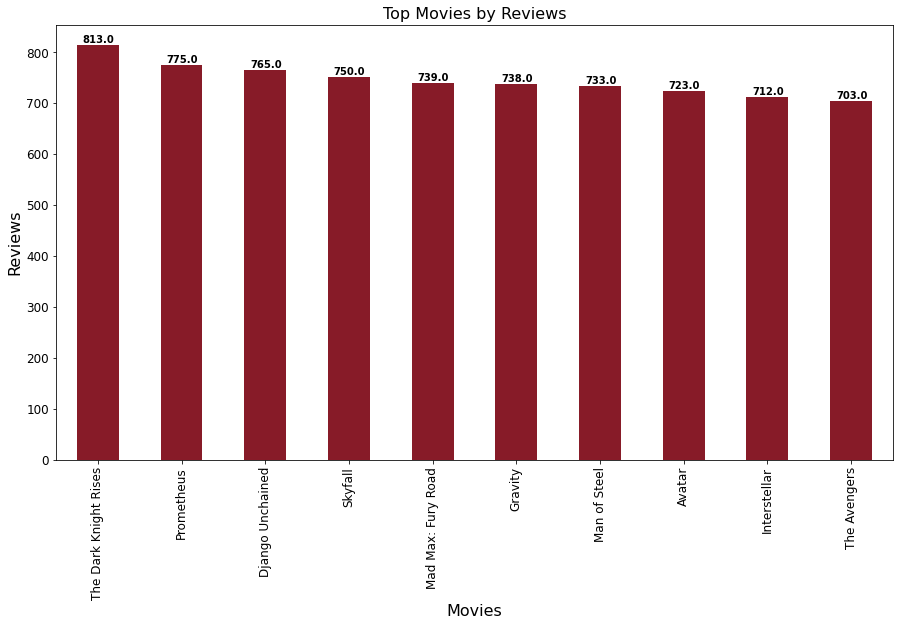

```python
data.groupby('Title')['Total Reviews'].sum().nlargest(10).plot(kind='bar', figsize=(15,8), color='#871b28');
plt.xlabel('Movies', fontsize=font_size1);
plt.ylabel('Reviews', fontsize=font_size1);
plt.title('Top Movies by Reviews', fontsize=font_size1);
plt.xticks(fontsize= font_size2);
plt.yticks(fontsize= font_size2);

for num, value in enumerate(data.groupby('Title')['Total Reviews'].sum().nlargest(10)):
        plt.text(num-0.18, value+5, str(np.round(value, decimals = 1)), fontweight='bold');
```

#### Top Movies by Duration

- 5 hours and 30 minutes are the duration of the longest movie which is an american crime movie Blood In, Blood Out, in 1993.

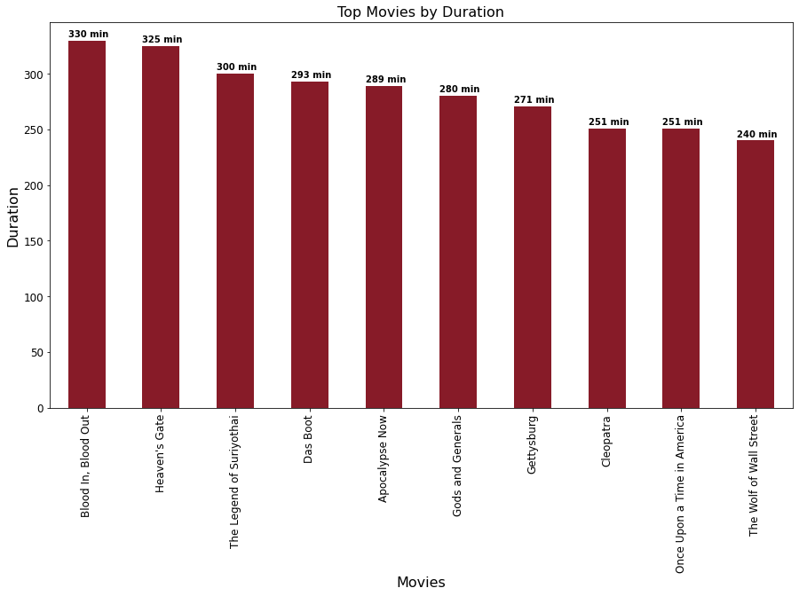

```python
data.groupby('Title')['Duration (min)'].sum().nlargest(10).plot(kind='bar', figsize=(15,8), color='#871b28');
plt.xlabel('Movies', fontsize=font_size1);
plt.ylabel('Duration', fontsize=font_size1);
plt.title('Top Movies by Duration', fontsize=font_size1);
plt.xticks(fontsize= font_size2);
plt.yticks(fontsize= font_size2);

for num, value in enumerate(data.groupby('Title')['Duration (min)'].sum().nlargest(10)):
        plt.text(num-0.25, value+np.exp(1.2), str(np.round(value, decimals = 1))+' min', fontweight='bold');
```

#### Top Actors by Likes

- Johnny Depp is the most liked actor by 1,320,000 likes and 33 movies, with total 3719 minutes of filming in Action, Biography, and Drama.

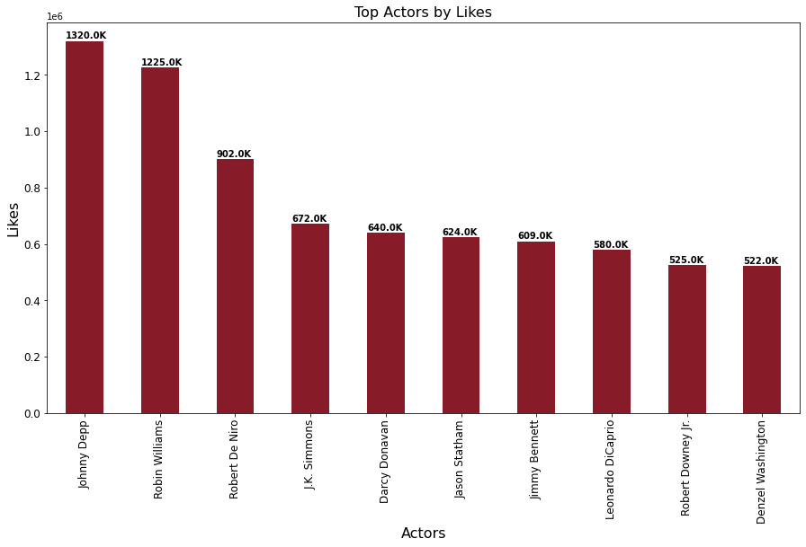

```python
data.groupby('Lead Actor')['Lead Actor FB Likes'].sum().nlargest(10).plot(kind='bar', figsize=(15,8), color='#871b28');
plt.xlabel('Actors', fontsize=font_size1);
plt.ylabel('Likes', fontsize=font_size1);
plt.title('Top Actors by Likes', fontsize=font_size1);
plt.xticks(fontsize= font_size2);
plt.yticks(fontsize= font_size2);

for num, value in enumerate(data.groupby('Lead Actor')['Lead Actor FB Likes'].sum().nlargest(10)):
        plt.text(num-0.25, value+np.exp(9), str(np.round(value/1000, decimals = 1))+'K', fontweight='bold');
```

#### Top Directors by Likes

- Steven Spielberg is the most liked Director with 336,000 likes, he directed 24 movies, 23 were in USA, and 14 of them were Action and Drama.

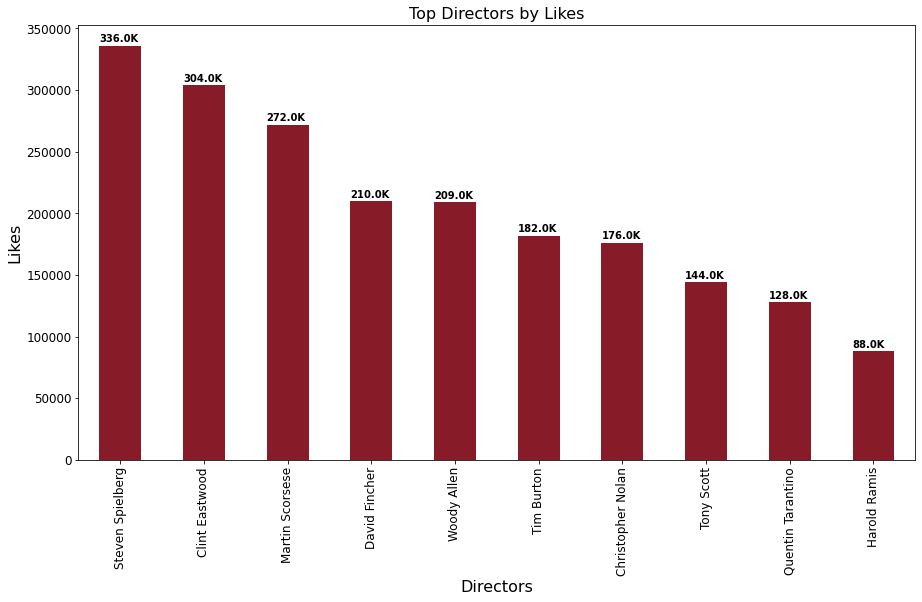

```python
data.groupby('Director Name')['Director FB Likes'].sum().nlargest(10).plot(kind='bar', figsize=(15,8), color='#871b28');
plt.xlabel('Directors', fontsize=font_size1);
plt.ylabel('Likes', fontsize=font_size1);
plt.title('Top Directors by Likes', fontsize=font_size1);
plt.xticks(fontsize= font_size2);
plt.yticks(fontsize= font_size2);

for num, value in enumerate(data.groupby('Director Name')['Director FB Likes'].sum().nlargest(10)):
        plt.text(num-0.25, value+np.exp(8), str(np.round(value/1000, decimals = 1))+'K', fontweight='bold');
```

### Budget & Revenue

#### Highest Budget Movies

- The Host movie has the highest budget as it has a budget about 12.2 billion dollars.

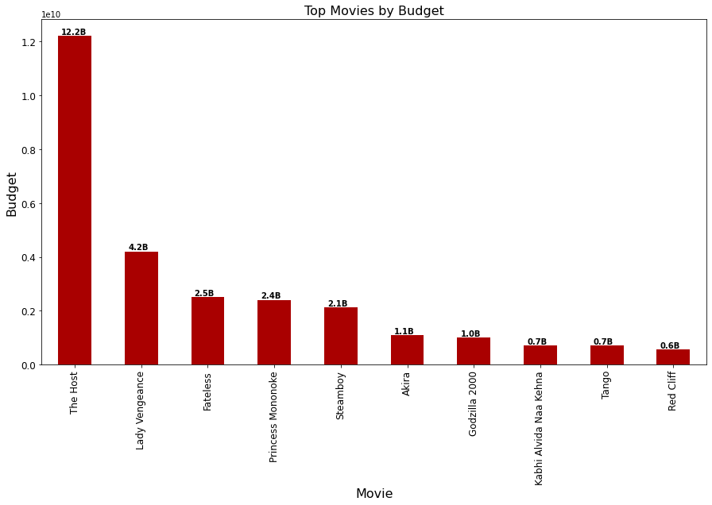

```python
data.groupby('Title')['Budget'].sum().nlargest(10).plot(kind='bar', figsize=(15,8), color='#a90000');

plt.xlabel('Movie', fontsize=font_size1);
plt.ylabel('Budget', fontsize=font_size1);
plt.title('Top Movies by Budget', fontsize=font_size1);
plt.xticks(fontsize= font_size2);
plt.yticks(fontsize= font_size2);

for num, value in enumerate(data.groupby('Title')['Budget'].sum().nlargest(10)):
        plt.text(num-0.2, value+np.exp(18), str(np.round(value/1000000000, decimals = 1))+'B', fontweight='bold');
```

#### Highest Revenue Movies

- Avatar movie has the highest revenue as it has a revenue about 760.5 million billion dollars.

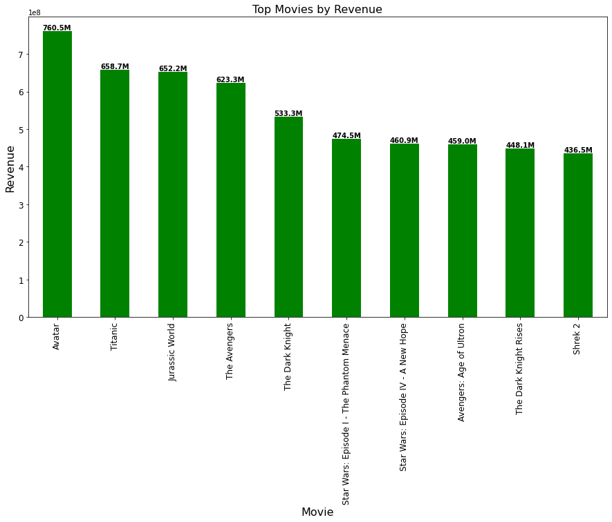

```python
data.groupby('Title')['Gross Revenue'].sum().nlargest(10).plot(kind='bar', figsize=(15,8), color='#008200');

plt.xlabel('Movie', fontsize=font_size1);
plt.ylabel('Revenue', fontsize=font_size1);
plt.title('Top Movies by Revenue', fontsize=font_size1);
plt.xticks(fontsize= font_size2);
plt.yticks(fontsize= font_size2);

for num, value in enumerate(data.groupby('Title')['Gross Revenue'].sum().nlargest(10)):
        plt.text(num-0.25, value+np.exp(15), str(np.round(value/1000000, decimals = 1))+'M', fontweight='bold');
```

#### Budget by Country

- USA has the highest budget, as it provided about 114,6 billion dollars for film making until 2015.

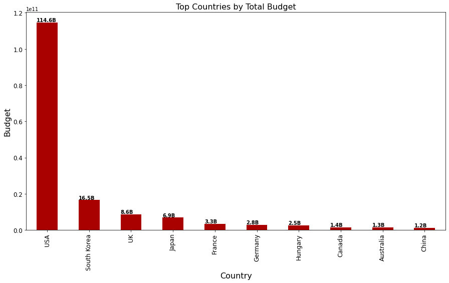

```python
data.groupby('Country')['Budget'].sum().nlargest(10).plot(kind='bar', figsize=(15,8), color='#a90000');

plt.xlabel('Country', fontsize=font_size1);
plt.ylabel('Budget', fontsize=font_size1);
plt.title('Top Countries by Total Budget', fontsize=font_size1);
plt.xticks(fontsize= font_size2);
plt.yticks(fontsize= font_size2);

for num, value in enumerate(data.groupby('Country')['Budget'].sum().nlargest(10)):
        plt.text(num-0.25, value+np.exp(20), str(np.round(value/1000000000, decimals = 1))+'B', fontweight='bold');
```

#### Revenue by Country

- USA has the highest revenue, as it gained about 165,6 billion dollars from film making from 1920 until 2015.

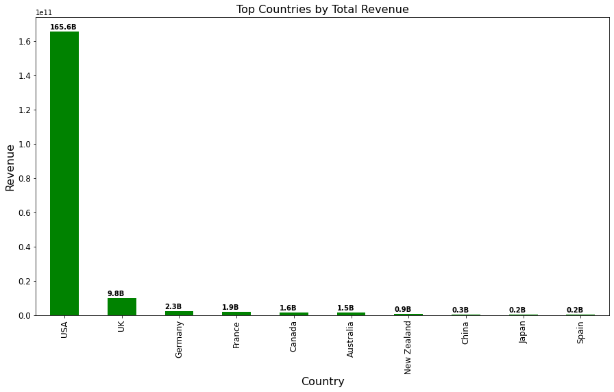

```python
data.groupby('Country')['Gross Revenue'].sum().nlargest(10).plot(kind='bar', figsize=(15,8), color='#008200');

plt.xlabel('Country', fontsize=font_size1);
plt.ylabel('Revenue', fontsize=font_size1);
plt.title('Top Countries by Total Revenue', fontsize=font_size1);
plt.xticks(fontsize= font_size2);
plt.yticks(fontsize= font_size2);

for num, value in enumerate(data.groupby('Country')['Gross Revenue'].sum().nlargest(10)):
        plt.text(num-0.25, value+np.exp(21), str(np.round(value/1000000000, decimals = 1))+'B', fontweight='bold');
```